# 10-locus-summary-and-eval

Update: 15 March 2023

Updates: use the NAs explicit genos file. Don’t filter loci based on missing data at this point. Just look at reference pops for evaluating HWE.

23 February 2023

Evaluating the loci that we’re using for self-assignment and bycatch assignment.

These were originally derived from lcWGS data and the microhaplotype results suggest that the real variation present is potentially quite different.

Initially, I should probably just focus on the baseline genotypes rather than including everything.

To evaluate the markers, I need to subset the reference baseline genotypes for just the minimal amount of missing data.

```r
library(tidyverse)
library(adegenet)
library(radiator)
library(DescTools)
```

```r
# read in rds file with genotypes
genos_long <- read_rds("../data/processed/called_genos_na_explicit.rds")

# just select the reference samples based on metadata
samplesheets <- read_csv("../data/processed/full_metadata_w_samplesheet.csv")
reference_samples <- samplesheets %>%
  filter(Sample_Plate %in% c("BFAL001", "BFAL002") &
           !is.na(Location)) %>%
  arrange(Sample_ID) %>%
  select(Sample_ID, gtseq_run, id, Location, `Loc-Abbr`)

# combine the genotypes with the reference
ref_genos <- reference_samples %>%
  left_join(., genos_long, by = c("gtseq_run", "id"))
```

Deal explicitly with duplicate samples:

## Some initial filters

### Take highest read-depth call for multiply-genotyped DNA_IDs

I’m not sure if there are any of these, but best to leave it in here…

Now, here is a harder operation: if an individual is multiply-genotyped, take the genotype with the highest total read depth.

```r
# slow-ish function to get the total read depth column
tdepth <- function(a, d) {
  if(any(is.na(a))) {
    return(NA)
  }
  if(a[1]==a[2]) {
    return(d[1])
  } else {
    return(d[1] + d[2])
  }

}
# this takes the highest read-depth instance of each duplicately-genotyped individual.
geno_one_each <- ref_genos %>%
  group_by(Sample_ID, locus, gtseq_run) %>%
  mutate(total_depth = tdepth(allele, depth)) %>%
  ungroup() %>%
  arrange(Sample_ID, locus, total_depth, gtseq_run, depth) %>%
  group_by(Sample_ID, locus) %>%
  mutate(rank = 1:n()) %>% # this ranks all alleles for a given individual by depth
  ungroup() %>%
  filter(rank <= 2) # this takes the top ranked alleles and should remove duplicates


# how many samples now?
geno_one_each %>%
  filter(!is.na(Sample_ID)) %>%
  group_by(Sample_ID) %>%
  select(Sample_ID, gtseq_run, id) %>%
  unique() %>%
  tally()
```

| Sample_ID | n |
| --- | --- |
| 12-0155 | 1 |
| 12-0270 | 1 |
| 12-0271 | 1 |
| 12-0371 | 1 |
| 12-0372 | 1 |
| 12-0381 | 1 |
| 13-0991 | 1 |
| 13-1096 | 1 |
| 13-1187 | 1 |
| 13-1198 | 1 |

[output cut: 141 more lines]

```r
NA
```

Take a look at missing data overall:

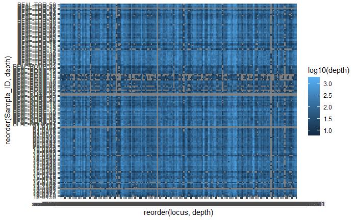

```r
geno_one_each %>%
  ggplot(aes(x = reorder(locus, depth), y = reorder(Sample_ID, depth), fill = log10(depth))) +
  geom_tile()
```

Deal with missing data:

## Missing data in loci

How many loci and how many alleles?

```r
# alleles
geno_one_each %>%
  filter(!is.na(allele)) %>%
  select(locus, allele) %>%
  unique()
```

| locus | allele |
| --- | --- |
| scaffold_0_4543438 | GGG |
| scaffold_0_4543438 | GGA |
| scaffold_1_5556176 | CT |
| scaffold_10_1333563 | G |
| scaffold_10_1333563 | A |
| scaffold_1050_36334 | T |
| scaffold_1053_177405 | A |
| scaffold_1078_116737 | GC |
| scaffold_11_3057945 | C |
| scaffold_115_2200290 | C |

[output cut: 448 more lines]

```r
# loci
geno_one_each %>%
  filter(!is.na(allele)) %>%
  select(locus, allele) %>%
  unique() %>%
  group_by(locus) %>%
  tally() %>%
  arrange(desc(n))
```

| locus | n |
| --- | --- |
| scaffold_1226_115783 | 6 |
| scaffold_1589_18141 | 5 |
| scaffold_316_437138 | 5 |
| scaffold_33_2811656 | 5 |
| scaffold_48_3128896 | 5 |
| scaffold_75_1184494 | 5 |
| scaffold_0_4543438 | 4 |
| scaffold_1164_119437 | 4 |
| scaffold_127_1105814 | 4 |
| scaffold_15_2923659 | 4 |

[output cut: 179 more lines]

```r
NA
```

In the reference, 458 alleles across 189 loci with 1-6 alleles per locus.

Some individuals are missing all their data, and some loci are missing all their data. Beginning with loci:

| locus |
| --- |
| scaffold_196_327438 |
| scaffold_30_2857044 |
| scaffold_81_820039 |
| scaffold_91_1220718 |

Remove these 4 loci because of too much missing data in the reference samples.

## Missing data in individuals

Total number of loci = 185

Total number of samples = 151

| Sample_ID | sum(missingness) |
| --- | --- |
| 21-0101 | 372 |
| BFAL-KURE-23 | 372 |
| BFAL-KURE-24 | 372 |
| BFAL-TOR-47 | 372 |
| 13-0991 | 362 |
| BFAL-PCMB-03 | 270 |
| BFAL-PCMB-15 | 228 |
| BFAL-PCMB-06 | 212 |
| BFAL-PCMB-11 | 208 |
| BFAL-PCMB-14 | 206 |

[output cut: 16 more lines]

26 samples removed with >10% missing data.

Now look at missing data:

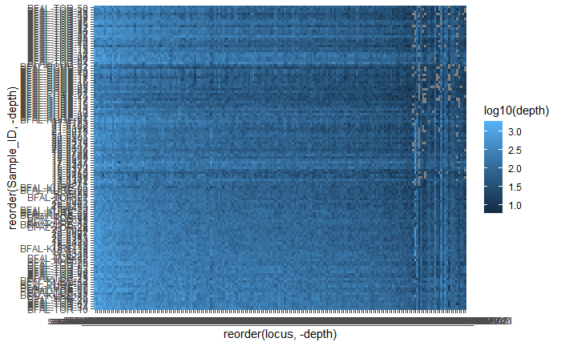

```r
genos_locs_ind_filtered %>%
  ggplot(aes(x = reorder(locus, -depth), y = reorder(Sample_ID, -depth), fill = log10(depth))) +
  geom_tile()
```

Much better. Now move forward from here.

## Prep data for analysis

```r
# first make integers of the alleles
alle_idxs <- genos_locs_ind_filtered %>%
  filter(!is.na(Sample_ID)) %>%
  dplyr::select(Sample_ID, locus, gene_copy, allele) %>%
  group_by(locus) %>%
  mutate(alleidx = as.integer(factor(allele, levels = unique(allele)))) %>%
  ungroup() %>%
  arrange(Sample_ID, locus, alleidx) # rubias can handle NA's, so no need to change them to 0's

# reformat
reference <- alle_idxs %>%
  inner_join(., reference_samples) %>%
  select(-allele, -gtseq_run, -id) %>%
  select(`Loc-Abbr`, Sample_ID, everything()) %>%
  rename(collection = `Loc-Abbr`, indiv = Sample_ID)
```

I need to finagle the dataset into a genind object.

```r
# read in data
reference_genos <- reference
```

Check on missing data:

```r
# if I removed all the indivs with > 10 missing alleles, that's only 5 indivs.
# what would the distribution of indivs per population be?
# still ok, I'm pretty sure.
reference_genos %>%
  anti_join(., inds_to_toss_missing_data) %>%
  group_by(collection, indiv) %>%
  tally() %>%
  tally()
```

| collection | n |
| --- | --- |
| Japan, Torishima | 40 |
| Kauai, Lehua | 2 |
| NWHI, FFS | 34 |
| NWHI, Kure | 22 |
| NWHI, Laysan | 8 |
| NWHI, Midway | 6 |

I feel fine about that. Let’s see if that makes any of the HWE calculations easier because less missing data?

```r
# SKIP THIS FOR NOW.
# ref_genos_low_missing_data <- reference_genos %>%
#   anti_join(., inds_to_toss_missing_data)

ref_genos_low_missing_data <- reference_genos
```

Make the df match the requirements for tidy_genomic_data

```r
long_df <- ref_genos_low_missing_data  %>%
  select(-gene_copy) %>%
  select(collection, everything()) %>%
  rename(INDIVIDUALS = indiv, STRATA = collection, MARKERS = locus, GT = alleidx)
```

Genotypes should be coded with 3 integers for each alleles. 6 integers in total for the genotypes. e.g. 001002 or 111333 (for heterozygote individual). 6 integers WITH separator: e.g. 001/002 or 111/333 (for heterozygote individual). The separator can be any of these: “/”, “:”, “_“,”-“,”.”, and will be removed.

```r
# create 3 digit integers from the genotypes
long_df$GT3 <- Format(long_df$GT, ldigits = 3, digits = 0)

# fix NAs
long_df0s <- long_df %>%
  mutate(GT3 = ifelse(is.na(GT3), "000", GT3)) # I don't love that this creates potential artifacts!
```

Now combine the GT3 column per indiv/marker:

```r
# make the genos characters and then try pasting them as strings
long_df0s$GT3 <- as.character(long_df0s$GT3)

long_df3digit <- long_df0s %>%
  group_by(INDIVIDUALS, MARKERS) %>%
  arrange(GT3, .by_group = TRUE) %>%
  summarise(GENOTYPE = toString(GT3))
# paste strings together
long_df3digit$GENOTYPE <- gsub(", ","",long_df3digit$GENOTYPE)


# add back on species identity as strata
df_for_conversion <- long_df0s %>%
  select(-GT, -GT3) %>%
  left_join(., long_df3digit) %>%
  unique() %>%
  rename(GT = GENOTYPE) %>%
  mutate(GT = ifelse(GT == "000000", NA, GT)) %>%
  filter(!str_detect(STRATA, "Kauai"))
df_for_conversion$STRATA <- as.factor(df_for_conversion$STRATA)
```

Double check - how many samples per population?

```r
df_for_conversion %>%
  select(INDIVIDUALS, STRATA) %>%
  unique() %>%
  group_by(STRATA) %>%
  tally()
```

| STRATA | n |
| --- | --- |
| Japan, Torishima | 43 |
| NWHI, FFS | 34 |
| NWHI, Kure | 24 |
| NWHI, Laysan | 9 |
| NWHI, Midway | 13 |

```r
NA
```

Let’s remove Lehua and Kilauea at this point because of so few samples.

```r
convert_df_wo_2pops <- df_for_conversion
```

```r
# use the radiator package for this conversion
genind_df <- write_genind(convert_df_wo_2pops)
```

Basic population genetic evaluation of the markers, following, in part, this: https://bookdown.org/hhwagner1/LandGenCourse_book/WE_3.html

```r
sum_output <- summary(genind_df)

names(sum_output)
```

```
[1] "n"         "n.by.pop"  "loc.n.all" "pop.n.all" "NA.perc"   "Hobs"      "Hexp"
```

```r
expected_hz <- as.data.frame(sum_output$Hexp)
observed_hz <- as.data.frame(sum_output$Hobs)
```

```r
# expected heterozygosity per population
adegenet::Hs(genind2genpop(genind_df))
```

```
 Converting data from a genind to a genpop object...

...done.

Japan,_Torishima        NWHI,_FFS       NWHI,_Kure     NWHI,_Laysan     NWHI,_Midway
       0.3155225        0.3617960        0.3531330        0.3728518        0.3436854
```

```r
Hobs <- t(sapply(seppop(genind_df), function(ls) summary(ls)$Hobs))
  Hexp <- t(sapply(seppop(genind_df), function(ls) summary(ls)$Hexp))
  {cat("Expected heterozygosity (Hexp):", "\n")
  round(Hexp, 2)
  cat("\n", "Observed heterozygosity (Hobs):", "\n")
  round(Hobs, 2)}
```

```r
par(mar=c(5.5, 4.5, 1, 1))
  Hobs.pop <- apply(Hobs, MARGIN = 1, FUN = mean)
  Hexp.pop <- apply(Hexp, 1, mean)
  barplot(Hexp.pop, ylim=c(0,1), las=3, ylab="Expected heterozygosity")
  barplot(Hobs.pop, ylim=c(0,1), las=3, ylab="Observed heterozygosity")
```

[output not shown]

```r
#install.packages("PopGenReport")

# Richness <- PopGenReport::allel.rich(genind_df, min.alleles = NULL)
# Richness$alleles.sampled
```

```r
bfal_diversity <- data.frame(Pop = names(Hobs.pop),
                              n_samples = sum_output$n.by.pop,
                              Hobs = Hobs.pop,
                              Hexp = Hexp.pop)
                              #Ar = Richness$mean.richness)
as.tibble(bfal_diversity) %>%
  rename(Population = Pop, H_obs = Hobs, H_exp = Hexp) #%>%
```

| Population | n_samples | H_obs | H_exp |
| --- | --- | --- | --- |
| Japan,_Torishima | 43 | 0.3152038 | 0.3155225 |
| NWHI,_FFS | 34 | 0.3640101 | 0.3617960 |
| NWHI,_Kure | 24 | 0.3581989 | 0.3531330 |
| NWHI,_Laysan | 9 | 0.3488650 | 0.3728518 |
| NWHI,_Midway | 13 | 0.3564930 | 0.3436854 |

```r
  #write_csv("csv_outputs/reference_pop_hz_summary.csv")
```

chi^2: value of the classical chi-squared test statistic df: degrees of freedom of the chi-squared test Pr(chi^2 >): p-value of the chi-squared test (‘>’ indicates that the alternative is ‘greater,’ which is always the case for a chi-squared test) Pr.exact: p-value from an exact test based on Monte Carlo permutation of alleles (for diploids only). The default is B = 1000 permutations (set B = 0 to skip this test). Here we use the function ‘round’ with argument ‘digits = 3’ to round all values to 3 decimals.

https://rdrr.io/cran/pegas/man/hw.test.html

In this case, the degrees of freedom depend on the number alleles for a given locus.

```r
# HWE test for all loci - but really what we want is all loci in each population (farther below)
hwe_output <- round(pegas::hw.test(genind_df, B = 1000), digits = 3)
# which ones are statistically sign.
rownames_to_column(data.frame(hwe_output)) %>%
  filter(Pr.exact < 0.01)
```

| rowname | chi.2 | df | Pr.chi.2... | Pr.exact |
| --- | --- | --- | --- | --- |
| scaffold_0_4543438 | 26.026 | 6 | 0.000 | 0.000 |
| scaffold_116_1932131 | 10.461 | 1 | 0.001 | 0.001 |
| scaffold_123_1115977 | 13.937 | 3 | 0.003 | 0.001 |
| scaffold_127_1105814 | 19.592 | 6 | 0.003 | 0.003 |
| scaffold_1327_103421 | 138.216 | 3 | 0.000 | 0.000 |
| scaffold_164_1134575 | 39.857 | 1 | 0.000 | 0.000 |
| scaffold_185_1133045 | 11.771 | 1 | 0.001 | 0.001 |
| scaffold_185_1154507 | 7.736 | 1 | 0.005 | 0.003 |
| scaffold_306_944429 | 9.816 | 1 | 0.002 | 0.003 |
| scaffold_345_694649 | 16.403 | 1 | 0.000 | 0.000 |

[output cut: 17 more lines]

```r
NA
```

27 loci that are out of HWE globally. (included is the funky one, scaffold_75_1184494) [31 with the missing data indivs removed from the baseline]

After looking at the loci x population HWE info, I can remove any that are out of HWE in the majority of populations.

| population | locus | p_val |
| --- | --- | --- |
| Japan._Torishima | scaffold_0_4543438 | 2.617975e-02 |
| Japan._Torishima | scaffold_102_694013 | 5.012287e-01 |
| Japan._Torishima | scaffold_1050_36334 | 3.526669e-02 |
| Japan._Torishima | scaffold_1053_177405 | 7.808632e-01 |
| Japan._Torishima | scaffold_1078_116737 | 9.385071e-01 |
| Japan._Torishima | scaffold_10_1333563 | 8.787937e-01 |
| Japan._Torishima | scaffold_115_2200290 | 1.000000e+00 |
| Japan._Torishima | scaffold_1164_119437 | NA |
| Japan._Torishima | scaffold_116_1932131 | 2.230298e-02 |
| Japan._Torishima | scaffold_116_386790 | 8.759310e-01 |

[output cut: 920 more lines]

Remove loci that are statistically out of HWE in >3 populations (the majority).

That’s only 4 loci.

| locus |
| --- |
| scaffold_0_4543438 |
| scaffold_102_694013 |
| scaffold_1050_36334 |
| scaffold_1053_177405 |
| scaffold_1078_116737 |
| scaffold_10_1333563 |
| scaffold_115_2200290 |
| scaffold_1164_119437 |
| scaffold_116_1932131 |
| scaffold_116_386790 |

[output cut: 172 more lines]

Pivoting to a new Rmd `11-hwe-filtered-baseline-and-mixture.Rmd`.

```r
# Monte Carlo: p-value
HWE.test <- data.frame(sapply(seppop(genind_df),
                              function(ls) pegas::hw.test(ls, B=1000)[,4]))
HWE.test.MC <- t(data.matrix(HWE.test))
{cat("MC permuation test (p-values):", "\n")
round(HWE.test.MC,3)}
```

[output not shown]

[output cut: 9 more lines]

```r
data.frame(Chisq=apply(HWE.test.chisq<alpha, 1, mean))
```

[output not shown]

```r
data.frame(HWE.test.chisq)
```

[output not shown]

```r
Prop.pops.out.of.HWE <- data.frame(Chisq=apply(HWE.test.chisq<alpha, 1, mean),
           MC=apply(HWE.test.MC<alpha, 1, mean))
Prop.pops.out.of.HWE
```

[output not shown]

Check what’s going on here (above).

```r
Chisq.fdr <- matrix(p.adjust(HWE.test.chisq,method="fdr"),
                    nrow=nrow(HWE.test.chisq))
MC.fdr <- matrix(p.adjust(HWE.test.MC, method="fdr"),
                    nrow=nrow(HWE.test.MC))

Prop.pops.out.of.HWE <- data.frame(Chisq=apply(HWE.test.chisq<alpha, 1, mean),
           MC=apply(HWE.test.MC<alpha, 1, mean),
           Chisq.fdr=apply(Chisq.fdr<alpha, 1, mean),
           MC.fdr=apply(MC.fdr<alpha, 1, mean))
Prop.pops.out.of.HWE
```

[output not shown]

Correct for the number of tests:

```r
Chisq.fdr <- matrix(p.adjust(HWE.test.chisq,method="fdr"),
                    nrow=nrow(HWE.test.chisq))
MC.fdr <- matrix(p.adjust(HWE.test.MC, method="fdr"),
                    nrow=nrow(HWE.test.MC))

Prop.pops.out.of.HWE <- data.frame(Chisq=apply(HWE.test.chisq<alpha, 1, mean),
           MC=apply(HWE.test.MC<alpha, 1, mean),
           Chisq.fdr=apply(Chisq.fdr<alpha, 1, mean),
           MC.fdr=apply(MC.fdr<alpha, 1, mean))
Prop.pops.out.of.HWE
```

[output not shown]

### PCA

Now that the data is a genind object, go ahead and run the PCA.

Make PCA

```r
# Allele presence absence data are extracted and NAs replaced using tab:
datasetX <- tab(genind_df, NA.method="mean") # double check that is this the appropriate method.

# make PCA
dataset_pca1 <- dudi.pca(datasetX, center = TRUE, scannf = FALSE, scale=FALSE, nf = 1000)

# colors
mycol <- colorRampPalette(c("deepskyblue", "darkgreen", "brown", "midnightblue", "darkcyan", "slateblue", "purple4"))(6)

# plot with factor labels
pdf("pdf_outputs/BFALgtseq_reference_filtered_genos_pca.pdf", width = 10, height = 10)
s.class(dataset_pca1$li, fac=pop(genind_df), wt = rep(1, length(pop(genind_df))), clabel = .8, grid = FALSE, cellipse = 2,
        xax=1, yax=2, col=transp(mycol,.8),
        axesel=FALSE, cstar=0, cpoint=1)
dev.off()
```

Out of curiosity, filter the genind to remove Torishima and then re-run the PCA with just the Hawaiian colonies.

```r
# remove Torishima for test PCA
convert_wo_3pops <- convert_df_wo_2pops %>%
  filter(STRATA != "Torishima")

# use the radiator package for this conversion
genind_wo_Torishima <- write_genind(convert_wo_3pops)


# Allele presence absence data are extracted and NAs replaced using tab:
dataset_wo_Tor <- tab(genind_wo_Torishima, NA.method="mean") # double check that is this the appropriate method.

# make PCA
dataset_wo_Tor1 <- dudi.pca(dataset_wo_Tor, center = TRUE, scannf = FALSE, scale=FALSE, nf = 1000)

# colors
mycol <- colorRampPalette(c("deepskyblue", "darkgreen", "brown", "midnightblue", "darkcyan", "slateblue", "purple4"))(6)

# plot with factor labels
pdf("pdf_outputs/BFALgtseq_reference_filtered_genos_pca_wo_Torishisma.pdf", width = 10, height = 10)
s.class(dataset_wo_Tor1$li, fac=pop(genind_wo_Torishima), wt = rep(1, length(pop(genind_wo_Torishima))), clabel = .8, grid = FALSE, cellipse = 2,
        xax=1, yax=2, col=transp(mycol,.8),
        axesel=FALSE, cstar=0, cpoint=1)
dev.off()
```

## Check on a few of the multi-hap loci from test 5

These looks funky: scaffold_75_1184494 scaffold_7_15896

These are also two loci that came up as out of HWE. Perfect. I’ll remove them and the other loci that had HWE issues across the majority of pops.

```r
reference_genos %>%
  filter(locus %in% c("scaffold_7_15896", "scaffold_75_1184494"))
```

[output not shown]

[output cut: 506 more lines]

```r
NA
NA
```